# Note-Attention Mechanism

Weiquan Luo

2021-07-31

# Introduction

Attention mechanism is to solve the *Information Overload* problem by weighting more on the importance elementS during the trainning.

```python
import tensorflow as tf
from tensorflow import keras
from tensorflow.keras import layers
print("Version: TensorFlow", tf.__version__)
```

```
Version: TensorFlow 2.5.0
```

## Type of Attention

| Category | type of attention | Example usage | Advantage | Disadvantage |
| --- | --- | --- | --- | --- |
| Number of position | hard [Xu et al., 2015](https://arxiv.org/abs/1502.03044) | 选取注意力分布中概率最高的输入向量，即最大采样, selects one patch of the image to attend to at a time, i.e. maxpooling, gating, Reinforcement Learning | While less expensive at inference time | hard to train due to non-differentiable and requires more complicated techniques |
| Number of position | *soft/global* [MT Luong et. al, 2015](https://arxiv.org/abs/1508.04025) | by gradient descent, weights are placed “softly" on value vector i.e. word vector, image pixel, channel | non-local dependency, long-term dependency | it has to attend to value on the source side for each key, which is High computational expensive |
| Number of position | local [Xu et al.2015](https://arxiv.org/abs/1502.03044) [MT Luong et. al, 2015](https://arxiv.org/abs/1508.04025) | balance the trade of between soft/global and hard attention by manually restrict on receptive field | avoiding the expensive computation, easier to train approach |  |
| Number of sequences | distinctive [Bahdanau et al., 2014](https://arxiv.org/abs/1409.0473) | key and value are not the same |  |  |
| Number of sequences | co-attention J Lu · 2016 | fuse attention with Cartesian product on attention map of query and key | feature crosses |  |
| Number of sequences | *self-attention* [A Vaswani, 2017](https://arxiv.org/abs/1706.03762) | soft adressing that query and key are identical | identical to soft attention |  |
| abstraction levels | single-level | attention weights are computed only for the original input sequence |  |  |
| abstraction levels | multi-level [Zhao and Zhang, 2018](https://aaai.org/ocs/index.php/AAAI/AAAI18/paper/view/16534) [Z Yang et al., 2016](https://aclanthology.org/N16-1174/) | multiple attentions are applied in a sequential manner on multiple levels . i.e. word to sentense to article | to understand different abstraction level of the input sequence from low to high |  |
| representation | multi-representation [Kiela et al. , 2018](https://arxiv.org/abs/1804.07983) | use different word embeddings for the same input sentence | capture different aspects of the input through multiple feature representations i.e. lexical, syntactic, visual and genre information |  |
| representation | multi-dimensional [Lin et al. , 2017](https://arxiv.org/abs/1703.03130) | determine the relevance of each dimension of the input embedding vector | more effective sentence embedding representation and language understanding problem. |  |

Reference:

- [An Attentive Survey of Attention Models](https://arxiv.org/abs/1904.02874)
- [An Attentive Survey of Attention Models 中文译文](https://blog.csdn.net/shenziheng1/article/details/89323074)

# Soft attention

The most often use attention today is *soft attention*, which can use soft-addressing as the analogy.

## Mechanism: soft addressing

Addressing is a processing that sending query to find a key in a source and extract the value corresponding to the key. Hard addressing always has one query match one key, becuase the matching query and key are exactly same, whereas *soft addressing* allow one query match multiple key and result multiple values.

- Query: query to match other
- Key: key to be matched
- Value: information to be extracted

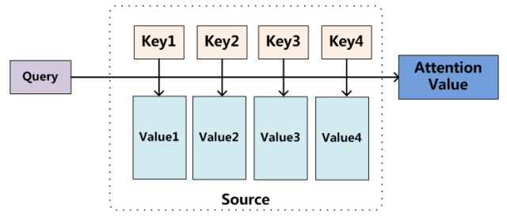

## Calculation step

The calculation of attention include three step:

1. Score function with Similarity: calculate the similarity of all key-value combination
2. Alignment function with softmax: convert similarity scores to attention weights
3. weighted summation: get a attention score by summing up the value adjusted with attention weights.

### Score function with Similarity

$z_i = similarity(q,k)$

Similarity

Formula for similarity(q,k)

Computational complexity

Bahdanau additive style  
`tf.reduce_sum(tf.tanh(query + key), axis=-1)`

$k^{T}tanh(w^{T}q+b)$

Dot product  
(luong multiplicative style)  
`tf.matmul(query, key, transpose_b=True)`

$k^T q$

点积注意力在实践中更快速且参数空间更高效，因为它能通过高度优化的矩阵乘法库并行地计算。 点积模型可以更好的利用矩阵乘积，计算效率更高。

Bilearning

$k^T W q$  
$= k^T (L^T H)q = (k L)^T (R q)$

相比点积模型，双线性模型在计算相似度时引入了非对称性

Cosine similarity

$\frac{k^T q}{\left|k\right| \left|q\right|}$

Scaled-Dot Attention

$\frac{k^T q}{\sqrt{d}}$

当输入向量的维度较高时，点积模型的值通常由较大的方差，从而导致 Softmax 函数的梯度会比较小。而缩放点积模型可以较好的解决这个问题。

Self-attention  
(multihead-attention when head =1 )

$\frac{(W_k k)^T(W_q q)}{\sqrt{d}}$

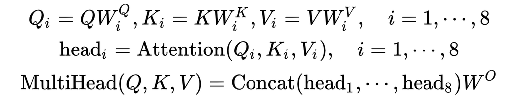

### Alignment function with softmax

softmax activation amplifies the important element (Value) of the input vector, resulting the importance weights $\alpha_i$ of each element:

$\alpha_i = \sigma(\vec{z}_{i}) = \frac{e^{z_i}}{\sum_{j=1}^{K} e^{z_j}}$

Where:

- step 1. $e^{z_i}$ exponentially transforms each element of the input vector to $(0,\infty]$. The value will be very small if the input was negative, and very large if the input was large.
- step 2. $\frac{e^{z_i}}{\sum_{j=1}^{K} e^{z_j}}$ normalization ensures that all the output values of the function will sum to 1 and each be in the range $(0, 1)$.

### Weighted summation

Weighted summation aggregate the weighted score to a single attention score:

$attention(q, v) = v_i^*= \sum \alpha_i v_i$

where:

- step 1. $\alpha_i v_i$ adjusts by the attention weights.
- step 2. $\sum \alpha_i v_i$ sums up the the weighted feature map .

## Example code

```python
# Query-value attention of shape [batch_size, Tq, filters].
query = tf.keras.Input(shape=[8, 16], name='query')
value = tf.keras.Input(shape=[4, 16], name='value')
```

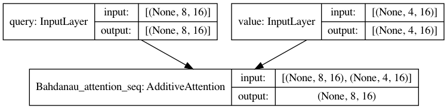

```python
# Bahdanau attention
Bahdanau_attention_seq = layers.AdditiveAttention(name = 'Bahdanau_attention_seq')([query, value])
model = keras.Model(
    inputs=[query, value],
    outputs=[Bahdanau_attention_seq]
)
keras.utils.plot_model(model, show_shapes=True)
```

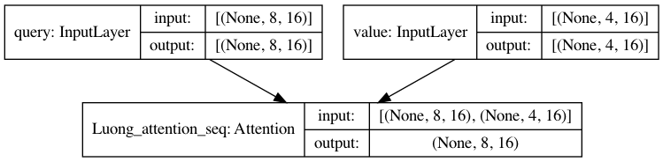

```python
# Luong attention
Luong_attention_seq = layers.Attention(name = 'Luong_attention_seq')([query, value])
model = keras.Model(
    inputs=[query, value],
    outputs=[Luong_attention_seq]
)
keras.utils.plot_model(model, show_shapes=True)
```

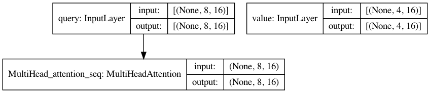

```python
# self attention
self_attention_seq = layers.MultiHeadAttention(num_heads=1, key_dim=2, name = 'MultiHead_attention_seq')(query, value)
model = keras.Model(
    inputs=[query, value],
    outputs=[self_attention_seq]
)
keras.utils.plot_model(model, show_shapes=True)
```

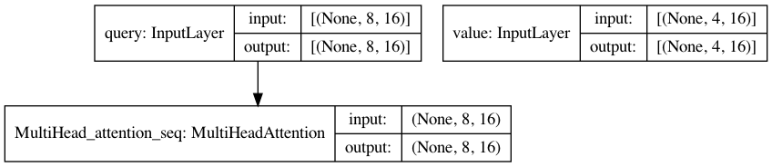

```python
# MultiHead attention
MultiHead_attention_seq = layers.MultiHeadAttention(num_heads=2, key_dim=2, name = 'MultiHead_attention_seq')(query, value)
model = keras.Model(
    inputs=[query, value],
    outputs=[MultiHead_attention_seq]
)
keras.utils.plot_model(model, show_shapes=True)
```

# CBAM module

CBAM module is a widely used attention module in computer vision that apply several types of attention.

## Mechanism: Channel + spatial attention

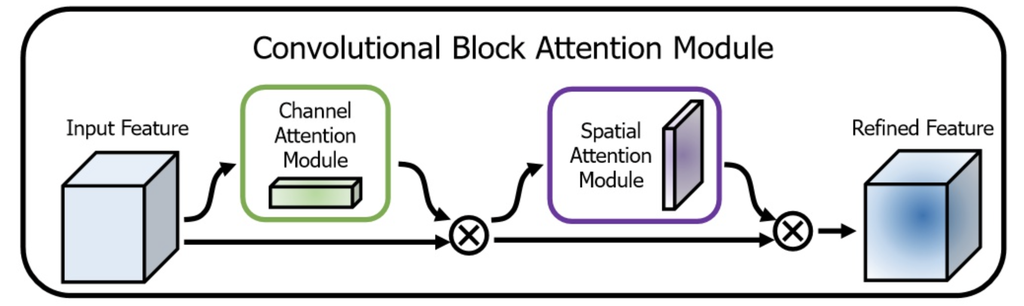

Reference:  
CBAM: Convolutional Block Attention Module [https://arxiv.org/abs/1807.06521]

## Calculation step

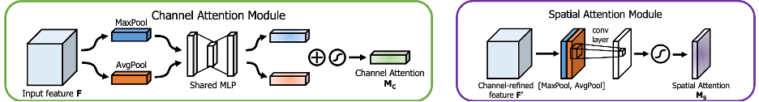

### Channel attention module

- Step 1. apply multiple representation, hard attention to result attention weights on each channel.
- Step 2. aggregate then activated attention weights from all representations with pairwise addition.
- Step 3. soft adressing the feature map with the aggregated channel-attention weights

### Spatial attention module

- Step 1. apply multiple representation, hard attention to result attention weights on each pixel.
- Step 2. aggregate then activated attention weights from all representations with dimensionality reduction.
- Step 3. soft adressing the feature map with the aggregated spatial-attention weights

## Example code

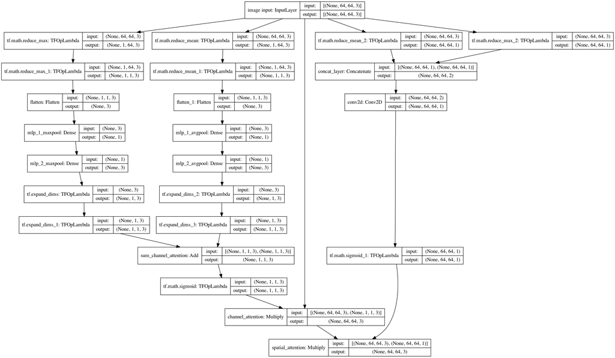

```python
def cbam_module(inputs,reduction_ratio=0.5,name=""):
    batch_size,channel_num=inputs.get_shape().as_list()[0],inputs.get_shape().as_list()[3]

    # Channel attention module
    maxpool_channel=tf.reduce_max(tf.reduce_max(inputs,axis=1,keepdims=True),axis=2,keepdims=True)
    avgpool_channel=tf.reduce_mean(tf.reduce_mean(inputs,axis=1,keepdims=True),axis=2,keepdims=True)

    maxpool_channel = layers.Flatten()(maxpool_channel)
    avgpool_channel = layers.Flatten()(avgpool_channel)

    mlp_1_max=layers.Dense(units=int(channel_num*reduction_ratio),name="mlp_1_maxpool",activation=tf.nn.relu)(maxpool_channel)
    mlp_2_max=layers.Dense(units=channel_num,name="mlp_2_maxpool")(mlp_1_max)
    mlp_2_max=tf.expand_dims(tf.expand_dims(mlp_2_max, 1), 1)

    mlp_1_avg=layers.Dense(units=int(channel_num*reduction_ratio),name="mlp_1_avgpool",activation=tf.nn.relu)(avgpool_channel)
    mlp_2_avg=layers.Dense(units=channel_num,name="mlp_2_avgpool")(mlp_1_avg)
    mlp_2_avg=tf.expand_dims(tf.expand_dims(mlp_2_avg, 1), 1)

    channel_attention=layers.Add(name='sum_channel_attention')([mlp_2_max,mlp_2_avg])
    channel_attention=tf.math.sigmoid(channel_attention)
    channel_refined_feature=layers.Multiply(name="channel_attention")([inputs,channel_attention])

    # Spatial attention module
    maxpool_spatial=tf.math.reduce_max(inputs,axis=3,keepdims=True)
    avgpool_spatial=tf.math.reduce_mean(inputs,axis=3,keepdims=True)
    max_avg_pool_spatial=layers.concatenate([maxpool_spatial,avgpool_spatial],axis=3,name="concat_layer")
    conv_layer=layers.Conv2D(filters=1, kernel_size=(7, 7), padding="same", activation=None)(max_avg_pool_spatial)
    spatial_attention=tf.math.sigmoid(conv_layer)

    refined_feature=layers.Multiply(name="spatial_attention")([channel_refined_feature,spatial_attention])

    return refined_feature

input_img = keras.Input(shape=[64, 64, 3], name='image input')
refined_feature = cbam_module(input_img)
model = keras.Model(inputs = [input_img], outputs = [refined_feature])
keras.utils.plot_model(model, show_shapes=True)
```